# SQ 010_prob

## Shared Qs (010_prob)

#### Question

1. In a deck of strange cards, there are 477 cards. Each card has an image and a color.

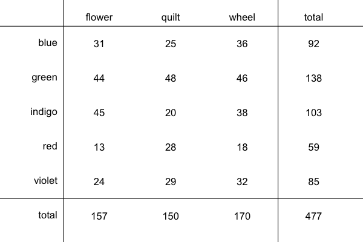

   1. What is the probability a random card is a flower?
   2. What is the probability a random card is violet?
   3. What is the probability a random card is both a flower and violet?
   4. What is the probability a random card is either a wheel or violet (or both)?
   5. What is the probability a random card is violet given it is a wheel?
   6. What is the probability a random card is a wheel given it is blue?
   7. Between a flower and a quilt, which is more likely to be a indigo?

#### Solution

#### Question

2. In a deck of strange cards, there are 609 cards. Each card has an image and a color.

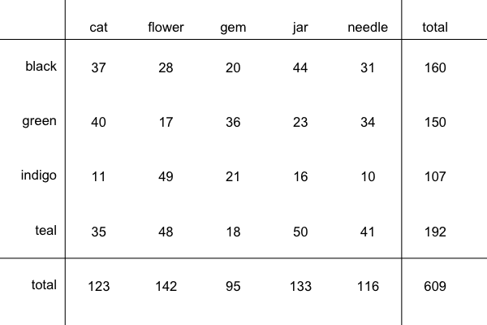

   1. What is the probability a random card is a cat?
   2. What is the probability a random card is indigo?
   3. What is the probability a random card is both a flower and indigo?
   4. What is the probability a random card is either a gem or teal (or both)?
   5. What is the probability a random card is black given it is a cat?
   6. What is the probability a random card is a cat given it is teal?
   7. Between a flower and a jar, which is more likely to be a teal?

#### Solution

#### Question

3. In a deck of strange cards, there are 342 cards. Each card has an image and a color.

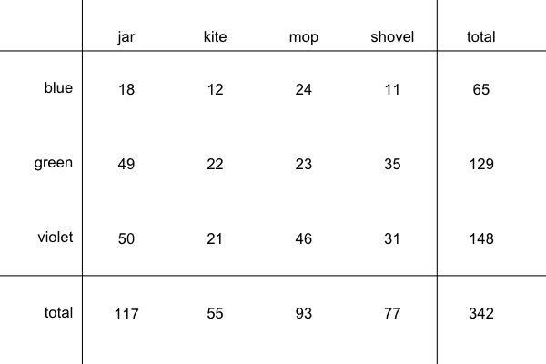

   1. What is the probability a random card is a shovel?
   2. What is the probability a random card is violet?
   3. What is the probability a random card is both a jar and blue?
   4. What is the probability a random card is either a jar or blue (or both)?
   5. What is the probability a random card is violet given it is a mop?
   6. What is the probability a random card is a mop given it is blue?
   7. Between a mop and a shovel, which is more likely to be a green?

#### Solution

#### Question

4. In a deck of strange cards, there are 432 cards. Each card has an image and a color.

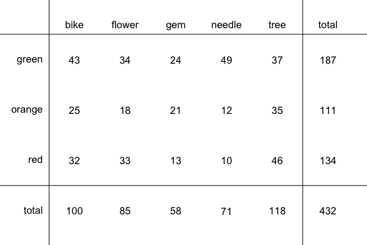

   1. What is the probability a random card is a bike?
   2. What is the probability a random card is green?
   3. What is the probability a random card is both a tree and green?
   4. What is the probability a random card is either a bike or orange (or both)?
   5. What is the probability a random card is orange given it is a bike?
   6. What is the probability a random card is a gem given it is green?
   7. Between a needle and a tree, which is more likely to be a orange?

#### Solution

#### Question

5. In a deck of strange cards, there are 447 cards. Each card has an image and a color.

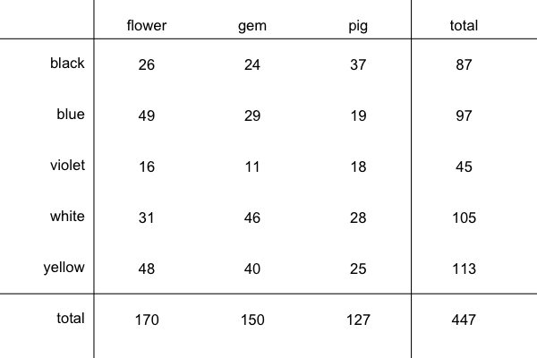

   1. What is the probability a random card is a flower?
   2. What is the probability a random card is violet?
   3. What is the probability a random card is both a gem and white?
   4. What is the probability a random card is either a gem or blue (or both)?
   5. What is the probability a random card is violet given it is a flower?
   6. What is the probability a random card is a pig given it is black?
   7. Between a flower and a pig, which is more likely to be a yellow?

#### Solution

#### Question

6. In a deck of strange cards, there are 461 cards. Each card has an image and a color.

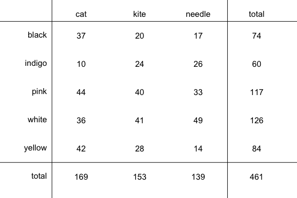

   1. What is the probability a random card is a kite?
   2. What is the probability a random card is black?
   3. What is the probability a random card is both a cat and yellow?
   4. What is the probability a random card is either a kite or yellow (or both)?
   5. What is the probability a random card is pink given it is a kite?
   6. What is the probability a random card is a needle given it is indigo?
   7. Between a kite and a needle, which is more likely to be a white?

#### Solution

#### Question

7. In a deck of strange cards, there are 444 cards. Each card has an image and a color.

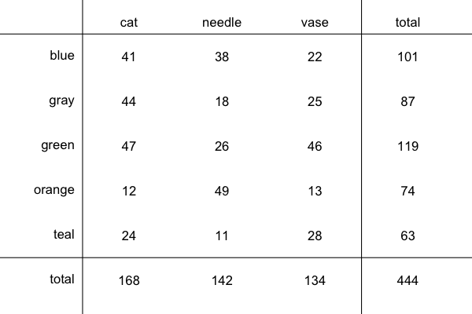

   1. What is the probability a random card is a cat?
   2. What is the probability a random card is gray?
   3. What is the probability a random card is both a cat and blue?
   4. What is the probability a random card is either a vase or orange (or both)?
   5. What is the probability a random card is blue given it is a vase?
   6. What is the probability a random card is a needle given it is teal?
   7. Between a cat and a vase, which is more likely to be a green?

#### Solution

#### Question

8. In a deck of strange cards, there are 477 cards. Each card has an image and a color.

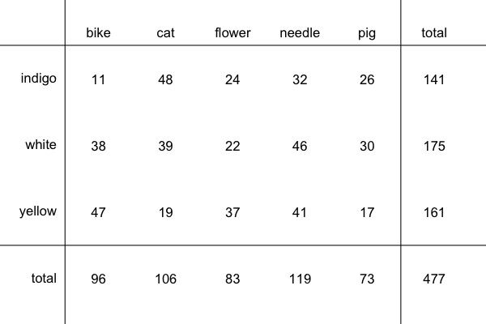

   1. What is the probability a random card is a cat?
   2. What is the probability a random card is white?
   3. What is the probability a random card is both a flower and white?
   4. What is the probability a random card is either a needle or indigo (or both)?
   5. What is the probability a random card is yellow given it is a needle?
   6. What is the probability a random card is a cat given it is white?
   7. Between a flower and a pig, which is more likely to be a yellow?

#### Solution

#### Question

9. In a deck of strange cards, there are 430 cards. Each card has an image and a color.

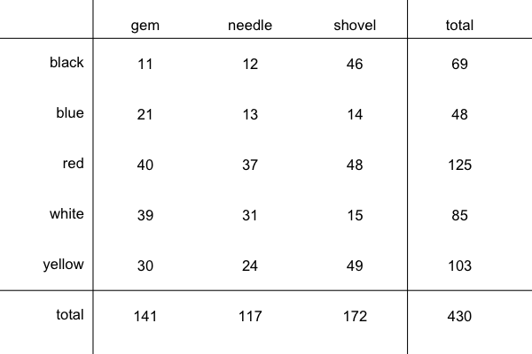

   1. What is the probability a random card is a shovel?
   2. What is the probability a random card is blue?
   3. What is the probability a random card is both a needle and red?
   4. What is the probability a random card is either a gem or white (or both)?
   5. What is the probability a random card is yellow given it is a shovel?
   6. What is the probability a random card is a needle given it is yellow?
   7. Between a needle and a shovel, which is more likely to be a red?

#### Solution

#### Question

10. In a deck of strange cards, there are 429 cards. Each card has an image and a color.

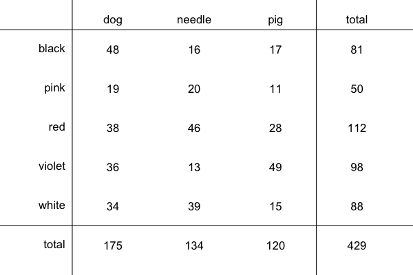

    1. What is the probability a random card is a dog?
    2. What is the probability a random card is black?
    3. What is the probability a random card is both a dog and pink?
    4. What is the probability a random card is either a needle or pink (or both)?
    5. What is the probability a random card is red given it is a pig?
    6. What is the probability a random card is a needle given it is pink?
    7. Between a dog and a pig, which is more likely to be a pink?

#### Solution

#### Question

11. In a deck of strange cards, there are 465 cards. Each card has an image and a color.

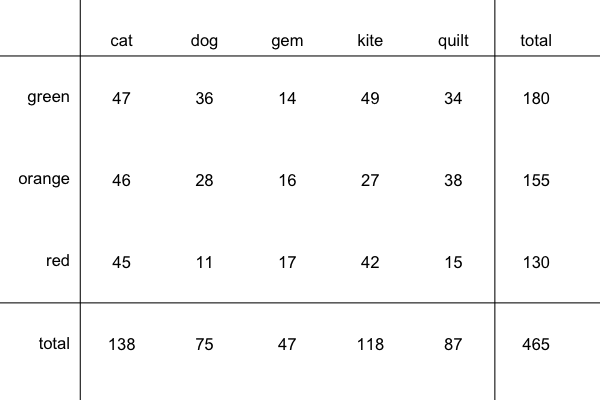

    1. Between a dog and a quilt, which is more likely to be a red?
    2. What is the probability a random card is both a cat and red?
    3. What is the probability a random card is red?
    4. What is the probability a random card is a quilt?
    5. What is the probability a random card is a gem given it is green?
    6. What is the probability a random card is green given it is a dog?
    7. What is the probability a random card is either a dog or orange (or both)?

#### Solution

#### Question

12. In a deck of strange cards, there are 431 cards. Each card has an image and a color.

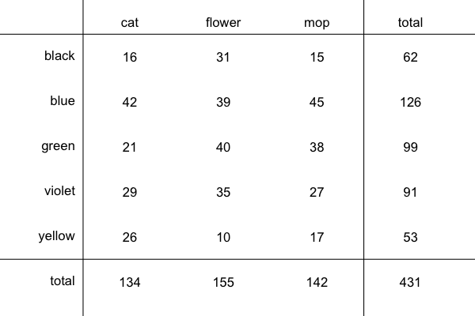

    1. What is the probability a random card is violet given it is a mop?
    2. What is the probability a random card is a flower given it is green?
    3. Between a cat and a mop, which is more likely to be a green?
    4. What is the probability a random card is either a flower or green (or both)?
    5. What is the probability a random card is violet?
    6. What is the probability a random card is both a flower and yellow?
    7. What is the probability a random card is a mop?

#### Solution

#### Question

13. In a deck of strange cards, there are 431 cards. Each card has an image and a color.

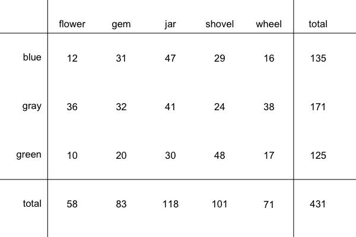

    1. What is the probability a random card is a wheel?
    2. What is the probability a random card is a shovel given it is gray?
    3. What is the probability a random card is both a flower and green?
    4. What is the probability a random card is blue?
    5. What is the probability a random card is either a wheel or green (or both)?
    6. What is the probability a random card is gray given it is a wheel?
    7. Between a jar and a wheel, which is more likely to be a blue?

#### Solution

#### Question

14. In a deck of strange cards, there are 427 cards. Each card has an image and a color.

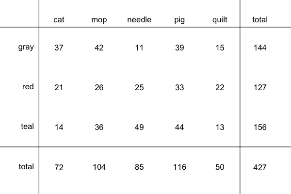

    1. What is the probability a random card is both a needle and gray?
    2. What is the probability a random card is teal?
    3. What is the probability a random card is a needle given it is red?
    4. What is the probability a random card is either a quilt or gray (or both)?
    5. Between a pig and a quilt, which is more likely to be a teal?
    6. What is the probability a random card is a pig?
    7. What is the probability a random card is gray given it is a mop?

#### Solution

#### Question

15. In a deck of strange cards, there are 501 cards. Each card has an image and a color.

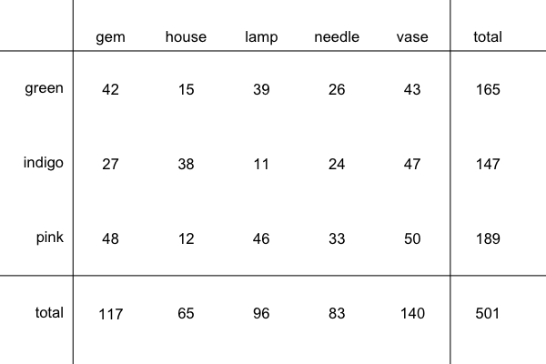

    1. What is the probability a random card is indigo?
    2. What is the probability a random card is green given it is a house?
    3. What is the probability a random card is either a gem or indigo (or both)?
    4. What is the probability a random card is a vase given it is green?
    5. Between a gem and a vase, which is more likely to be a green?
    6. What is the probability a random card is both a house and indigo?
    7. What is the probability a random card is a needle?

#### Solution

#### Question

16. In a deck of strange cards, there are 452 cards. Each card has an image and a color.

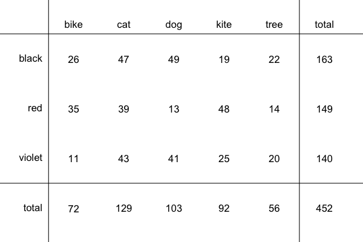

    1. What is the probability a random card is either a kite or red (or both)?
    2. What is the probability a random card is a cat given it is red?
    3. What is the probability a random card is both a cat and black?
    4. What is the probability a random card is black?
    5. What is the probability a random card is a cat?
    6. Between a bike and a cat, which is more likely to be a red?
    7. What is the probability a random card is violet given it is a kite?

#### Solution

#### Question

17. In a deck of strange cards, there are 514 cards. Each card has an image and a color.

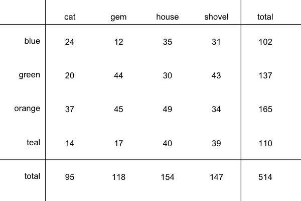

    1. What is the probability a random card is a cat given it is teal?
    2. Between a cat and a house, which is more likely to be a teal?
    3. What is the probability a random card is both a house and teal?
    4. What is the probability a random card is teal?
    5. What is the probability a random card is a house?
    6. What is the probability a random card is orange given it is a cat?
    7. What is the probability a random card is either a shovel or green (or both)?

#### Solution

#### Question

18. In a deck of strange cards, there are 508 cards. Each card has an image and a color.

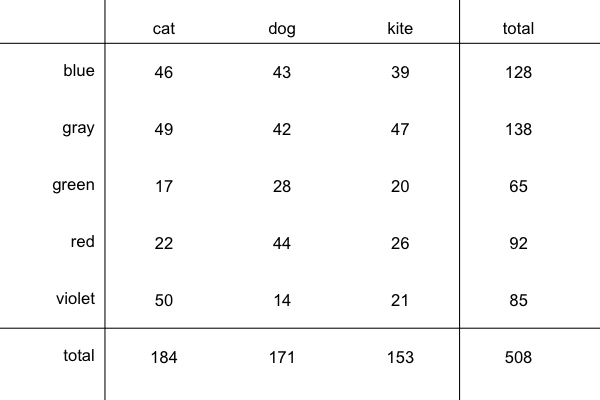

    1. What is the probability a random card is a dog?
    2. What is the probability a random card is violet given it is a kite?
    3. Between a cat and a dog, which is more likely to be a green?
    4. What is the probability a random card is either a kite or green (or both)?
    5. What is the probability a random card is a kite given it is violet?
    6. What is the probability a random card is both a kite and red?
    7. What is the probability a random card is violet?

#### Solution

#### Question

19. In a deck of strange cards, there are 458 cards. Each card has an image and a color.

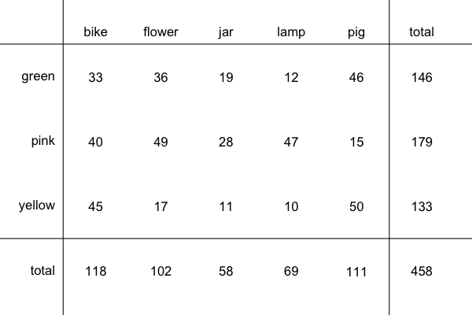

    1. Between a lamp and a pig, which is more likely to be a yellow?
    2. What is the probability a random card is both a bike and yellow?
    3. What is the probability a random card is a flower?
    4. What is the probability a random card is green?
    5. What is the probability a random card is a pig given it is green?
    6. What is the probability a random card is either a pig or green (or both)?
    7. What is the probability a random card is yellow given it is a lamp?

#### Solution

#### Question

20. In a deck of strange cards, there are 359 cards. Each card has an image and a color.

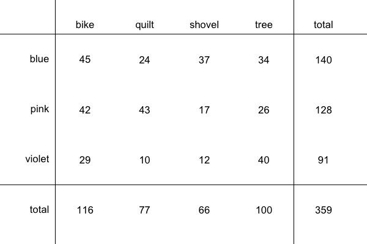

    1. What is the probability a random card is both a tree and blue?
    2. What is the probability a random card is pink?
    3. What is the probability a random card is a shovel given it is blue?
    4. Between a bike and a quilt, which is more likely to be a blue?
    5. What is the probability a random card is either a quilt or violet (or both)?
    6. What is the probability a random card is a shovel?
    7. What is the probability a random card is pink given it is a quilt?

#### Solution

#### Question

21. Cindy has two games today. Each game she will either win or lose. She has a 0.74 chance of winning the first game and a 0.49 chance of winning the second game.
    1. What is the chance Cindy wins both games?
    2. What is the chance Cindy loses both games?
    3. What is the chance Cindy wins once and loses once (in either order)?

#### Solution

#### Question

22. Cindy has two games today. Each game she will either win or lose. She has a 0.63 chance of winning the first game and a 0.41 chance of winning the second game.
    1. What is the chance Cindy wins both games?
    2. What is the chance Cindy loses both games?
    3. What is the chance Cindy wins once and loses once (in either order)?

#### Solution

#### Question

23. Cindy has two games today. Each game she will either win or lose. She has a 0.76 chance of winning the first game and a 0.39 chance of winning the second game.
    1. What is the chance Cindy wins both games?
    2. What is the chance Cindy loses both games?
    3. What is the chance Cindy wins once and loses once (in either order)?

#### Solution

#### Question

24. Cindy has two games today. Each game she will either win or lose. She has a 0.47 chance of winning the first game and a 0.73 chance of winning the second game.
    1. What is the chance Cindy wins both games?
    2. What is the chance Cindy loses both games?
    3. What is the chance Cindy wins once and loses once (in either order)?

#### Solution

#### Question

25. Cindy has two games today. Each game she will either win or lose. She has a 0.3 chance of winning the first game and a 0.62 chance of winning the second game.
    1. What is the chance Cindy wins both games?
    2. What is the chance Cindy loses both games?
    3. What is the chance Cindy wins once and loses once (in either order)?

#### Solution

#### Question

26. Cindy has two games today. Each game she will either win or lose. She has a 0.68 chance of winning the first game and a 0.26 chance of winning the second game.
    1. What is the chance Cindy wins both games?
    2. What is the chance Cindy loses both games?
    3. What is the chance Cindy wins once and loses once (in either order)?

#### Solution

#### Question

27. Cindy has two games today. Each game she will either win or lose. She has a 0.79 chance of winning the first game and a 0.28 chance of winning the second game.
    1. What is the chance Cindy wins both games?
    2. What is the chance Cindy loses both games?
    3. What is the chance Cindy wins once and loses once (in either order)?

#### Solution

#### Question

28. Cindy has two games today. Each game she will either win or lose. She has a 0.36 chance of winning the first game and a 0.61 chance of winning the second game.
    1. What is the chance Cindy wins both games?
    2. What is the chance Cindy loses both games?
    3. What is the chance Cindy wins once and loses once (in either order)?

#### Solution

#### Question

29. Cindy has two games today. Each game she will either win or lose. She has a 0.59 chance of winning the first game and a 0.38 chance of winning the second game.
    1. What is the chance Cindy wins both games?
    2. What is the chance Cindy loses both games?
    3. What is the chance Cindy wins once and loses once (in either order)?

#### Solution

#### Question

30. Cindy has two games today. Each game she will either win or lose. She has a 0.37 chance of winning the first game and a 0.68 chance of winning the second game.
    1. What is the chance Cindy wins both games?
    2. What is the chance Cindy loses both games?
    3. What is the chance Cindy wins once and loses once (in either order)?

#### Solution

#### Question

31. Bob has a 0.5 chance of winning a game. If Bob wins, he has a 0.86 chance of being happy after the game. If Bob loses, he has a 0.41 chance of being happy after the game.

    After the game, you notice Bob is happy. What is the probability that Bob won his game? (Do not answer as a percentage; answer as a decimal.)

#### Solution

#### Question

32. Bob has a 0.54 chance of winning a game. If Bob wins, he has a 0.7 chance of being happy after the game. If Bob loses, he has a 0.24 chance of being happy after the game.

    After the game, you notice Bob is happy. What is the probability that Bob won his game? (Do not answer as a percentage; answer as a decimal.)

#### Solution

#### Question

33. Bob has a 0.29 chance of winning a game. If Bob wins, he has a 0.7 chance of being happy after the game. If Bob loses, he has a 0.34 chance of being happy after the game.

    After the game, you notice Bob is happy. What is the probability that Bob won his game? (Do not answer as a percentage; answer as a decimal.)

#### Solution

#### Question

34. Bob has a 0.32 chance of winning a game. If Bob wins, he has a 0.55 chance of being happy after the game. If Bob loses, he has a 0.37 chance of being happy after the game.

    After the game, you notice Bob is happy. What is the probability that Bob won his game? (Do not answer as a percentage; answer as a decimal.)

#### Solution

#### Question

35. Bob has a 0.46 chance of winning a game. If Bob wins, he has a 0.6 chance of being happy after the game. If Bob loses, he has a 0.13 chance of being happy after the game.

    After the game, you notice Bob is happy. What is the probability that Bob won his game? (Do not answer as a percentage; answer as a decimal.)

#### Solution

#### Question

36. Bob has a 0.8 chance of winning a game. If Bob wins, he has a 0.87 chance of being happy after the game. If Bob loses, he has a 0.12 chance of being happy after the game.

    After the game, you notice Bob is happy. What is the probability that Bob won his game? (Do not answer as a percentage; answer as a decimal.)

#### Solution

#### Question

37. Bob has a 0.42 chance of winning a game. If Bob wins, he has a 0.52 chance of being happy after the game. If Bob loses, he has a 0.1 chance of being happy after the game.

    After the game, you notice Bob is happy. What is the probability that Bob won his game? (Do not answer as a percentage; answer as a decimal.)

#### Solution

#### Question

38. Bob has a 0.66 chance of winning a game. If Bob wins, he has a 0.73 chance of being happy after the game. If Bob loses, he has a 0.11 chance of being happy after the game.

    After the game, you notice Bob is happy. What is the probability that Bob won his game? (Do not answer as a percentage; answer as a decimal.)

#### Solution

#### Question

39. Bob has a 0.39 chance of winning a game. If Bob wins, he has a 0.57 chance of being happy after the game. If Bob loses, he has a 0.17 chance of being happy after the game.

    After the game, you notice Bob is happy. What is the probability that Bob won his game? (Do not answer as a percentage; answer as a decimal.)

#### Solution

#### Question

40. Bob has a 0.5 chance of winning a game. If Bob wins, he has a 0.61 chance of being happy after the game. If Bob loses, he has a 0.5 chance of being happy after the game.

    After the game, you notice Bob is happy. What is the probability that Bob won his game? (Do not answer as a percentage; answer as a decimal.)

#### Solution